# Renal Clear Cell Carcinoma Machine Learning Project

## Emily Isko and Joe Jessee

### Biof509: Applied Machine Learning

[figure not shown]

# Project Background

# FSGS, which is not Renal Clear Cell Carcinoma

- Focal Segmental Glomerulosclerosis, or FSGS, is a leading cause of ESRD in the United States
- There are several sub-types of FSGS. More on that later.
- It is a progressive disease with no targeted therapies
- The disease is characterized by its pathognomonic histological pattern, which is focal and segmental scarring of the glomerulus

[figure not shown]

# FSGS Histology

[figure not shown]

# FSGS Sub-types that result in the histology

- Primary FSGS: Idiopathic, thought to be caused by some circulating factor
- Adaptive/Secondary FSGS: Caused by a mismatch between glomerular demand and capacity
  - Born pre-mature (less nephrons per kidney) adulthood obesity (high-metabolic load)
- High-Penetrance Genetic FSGS
- HIV-Associated Nephropathy (HIVAN): Collapsing Variant of FSGS
- Drug-Induced FSGS: Nephrotoxic drug-related damage to glomerulus

# Why Sub-types are important in this case

- There are decisions related to the drug-regimen for each of the subtypes of FSGS
- The actual categories are controversial and are an active field of study
- Taxonomy of Kidney-Disease can be very difficult in general

# The general plan: Statistically-robust clustering of disease phenotypes

- This requires a complete dataset of FSGS patient data... which I am still acquiring
- In the meantime, the plan is to build out the pipeline on a public dataset of Renal Clear Cell Carcinoma data

# Public Dataset of Renal Clear Cell Carcinoma Cases

# Summary

# Clinical Data Exploration

```python
# Read in clinical data and separate target labels from data
clinical_info = pd.read_csv("cleaned_clinical.csv", index_col=1)
clinical_info = clinical_info.drop(['Unnamed: 0'], axis=1)
clinical_info = clinical_info.dropna(subset=['tumor_stage'])
clinical_info_without_target = clinical_info.loc[:, clinical_info.columns !='tumor_stage']
```

```python
print(clinical_info.info())
```

```
<class 'pandas.core.frame.DataFrame'>
Index: 534 entries, TCGA-BP-5198 to TCGA-B0-5691
Data columns (total 12 columns):
gender                    534 non-null object
year_of_birth             534 non-null float64
race                      534 non-null object
ethnicity                 534 non-null object
year_of_death             161 non-null float64
primary_diagnosis         534 non-null object
tumor_stage               534 non-null float64
age_at_diagnosis          533 non-null float64
vital_status              534 non-null object
days_to_death             176 non-null float64
days_to_last_follow_up    382 non-null float64
age_at_death              175 non-null float64
dtypes: float64(7), object(5)
memory usage: 54.2+ KB
None
```

## What to do with empty entries

In this data set, empty entries were often denoted with **--** or **not reported**

We changed this to NaN as appropriate.

```python
# replace '--' with Nan
clinical_info = clinical_info.replace('--', np.nan)
clinical_info = clinical_info.replace('not reported', np.nan)

# keep 'not reported' as categorical variable, ethnicity and race
clinical_info['ethnicity'] = clinical_info['ethnicity'].replace(np.nan, 'not reported')
clinical_info['race'] = clinical_info['race'].replace(np.nan, 'not reported')
```

```python
# looking at where the missing data are
print(clinical_info.isna().sum())

clinical_info.head()
```

```
gender                      0
year_of_birth               0
race                        0
ethnicity                   0
year_of_death             373
primary_diagnosis           0
tumor_stage                 0
age_at_diagnosis            1
vital_status                0
days_to_death             358
days_to_last_follow_up    152
age_at_death              359
dtype: int64
```

| submitter_id | gender | year_of_birth | race | ethnicity | year_of_death | primary_diagnosis | tumor_stage | age_at_diagnosis | vital_status | days_to_death | days_to_last_follow_up | age_at_death |
| --- | --- | --- | --- | --- | --- | --- | --- | --- | --- | --- | --- | --- |
| TCGA-BP-5198 | male | 1936.0 | white | not reported | NaN | Clear cell adenocarcinoma, NOS | 3.0 | 26360.0 | alive | NaN | 603.0 | NaN |
| TCGA-B0-4706 | male | 1946.0 | white | not hispanic or latino | 2007.0 | Clear cell adenocarcinoma, NOS | 3.0 | 22331.0 | dead | 65.0 | 26.0 | 22396.0 |
| TCGA-BP-4760 | male | 1935.0 | black or african american | not hispanic or latino | NaN | Clear cell adenocarcinoma, NOS | 1.0 | 25268.0 | alive | NaN | 2361.0 | NaN |
| TCGA-CZ-5462 | male | 1924.0 | white | not reported | 2007.0 | Clear cell adenocarcinoma, NOS | 4.0 | 30659.0 | dead | 311.0 | NaN | 30970.0 |
| TCGA-AK-3427 | male | 1939.0 | white | not hispanic or latino | NaN | Clear cell adenocarcinoma, NOS | 1.0 | 24067.0 | alive | NaN | 3583.0 | NaN |

```python
# New data frame only has 12 variables.
clinical_info.shape
```

```
(534, 12)
```

## Casting numerical data

We identified which variables should be encoded as numeric variables (anything related to year, age, or days) and converted the data types to floats.

```python
# convert columns with numbers to floats
to_float = ['year_of_birth','year_of_death', 'tumor_stage','age_at_diagnosis', 'days_to_death', 'days_to_last_follow_up']
for col in to_float:
    clinical_info[col] = clinical_info[col].astype('float64')

# add new column age_at_death
clinical_info['age_at_death'] = clinical_info['age_at_diagnosis'] + clinical_info['days_to_death']
clinical_info.info()
```

```
<class 'pandas.core.frame.DataFrame'>
Index: 534 entries, TCGA-BP-5198 to TCGA-B0-5691
Data columns (total 12 columns):
gender                    534 non-null object
year_of_birth             534 non-null float64
race                      534 non-null object
ethnicity                 534 non-null object
year_of_death             161 non-null float64
primary_diagnosis         534 non-null object
tumor_stage               534 non-null float64
age_at_diagnosis          533 non-null float64
vital_status              534 non-null object
days_to_death             176 non-null float64
days_to_last_follow_up    382 non-null float64
age_at_death              175 non-null float64
dtypes: float64(7), object(5)
memory usage: 54.2+ KB
```

# Is there redundancy among the variables?

We represented the data in a correlation matrix to identify redundant variables that may be encoding the same information.

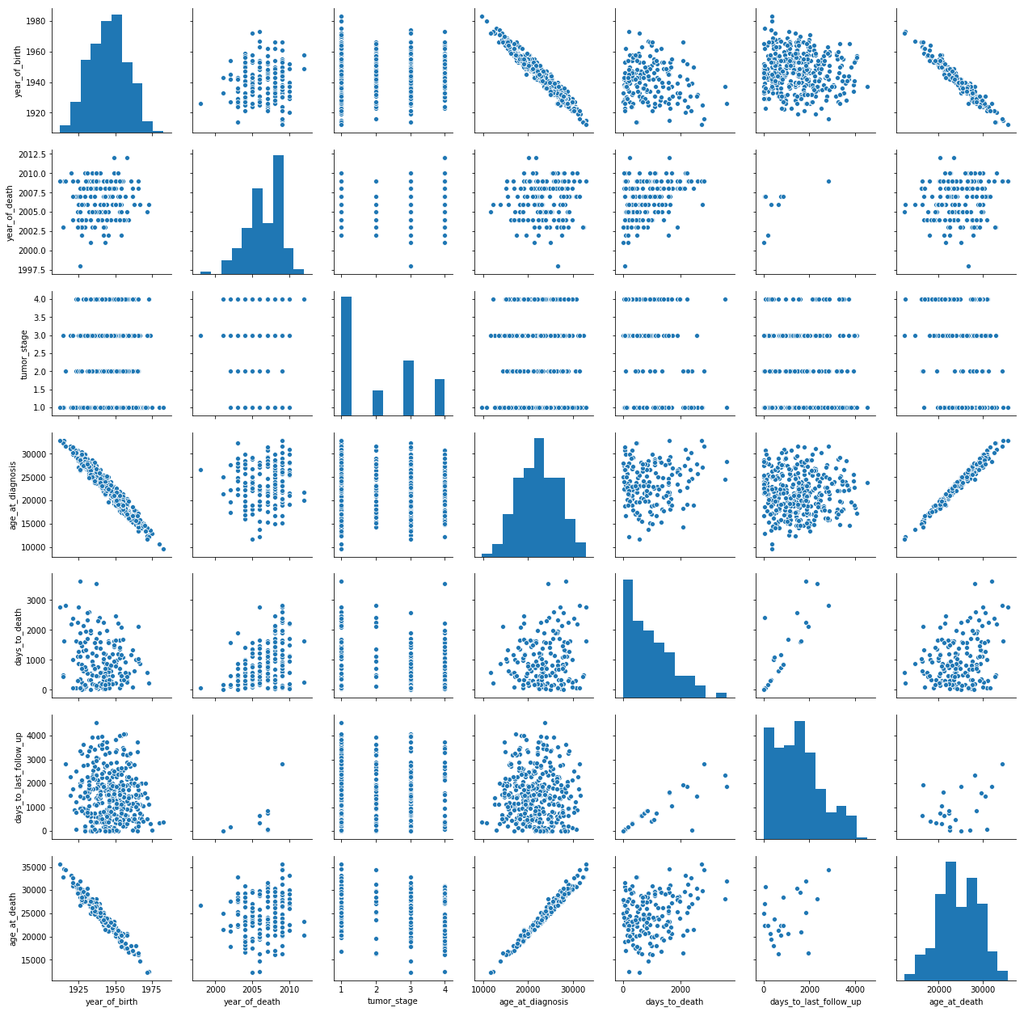

```python
%matplotlib inline
sb.pairplot(clinical_info)
```

# Yes, there is

- Three of the event-time type variables correlate with one another
  - Age at Diagnosis correlates with Age at Death because someone who is diagnosed when they are old may just live to be older
  - Age at Death correlates with Year of Birth. We suspect this is a sample bias. The patients were recruited in a recent period of time, and therefore the cross-section of patients examined would only include people who were diagnosed young and died young, and people who were diagnosed old and died when they were old.
  - Age at Diagnosis correlates with Year of Birth for a reason we have not determined

The variables that are all correlating with eachother are typical variables when trying to collect data for a Kaplan Meier Curve, which we have included later in the presentation

# Data visualization

```
object
gender  is a string type
float64
year_of_birth  is a number
object
race  is a string type
object
ethnicity  is a string type
float64
year_of_death  is a number
object
primary_diagnosis  is a string type
float64
tumor_stage  is a number
float64
age_at_diagnosis  is a number
object
vital_status  is a string type
float64
days_to_death  is a number
float64
days_to_last_follow_up  is a number
float64
age_at_death  is a number
```

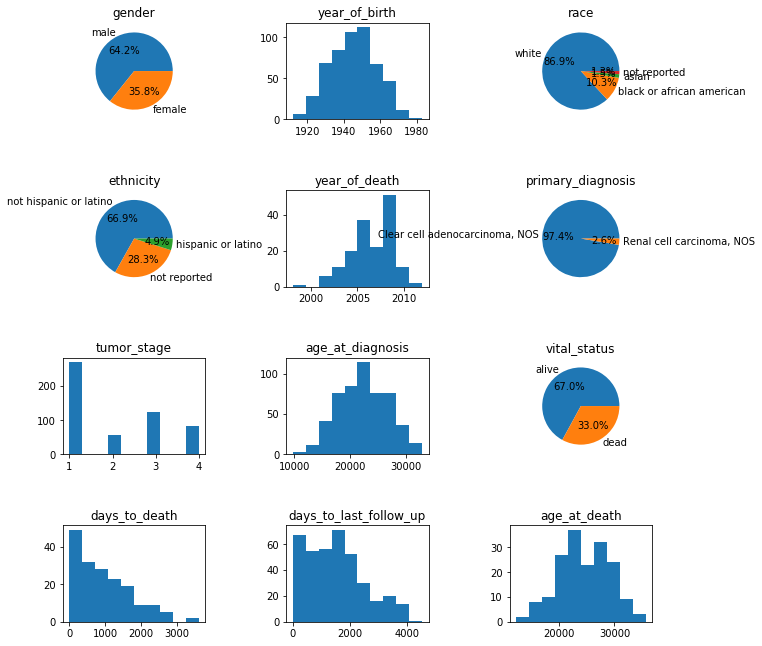

```python
from pandas.api.types import is_string_dtype

fig, axs = plt.subplots(4,3, figsize=(10,10))
fig.tight_layout(pad=5)
i = 0
j = 0

for col in clinical_info:
    print(clinical_info[col].dtype)
    dtype = clinical_info[col].dtype
    valcounts = clinical_info[col].value_counts()

    if col == "submitter_id":
        continue
    elif is_string_dtype(clinical_info[col]):
        print(clinical_info[col].name, " is a string type")
        vals = valcounts.values.tolist()
        names = valcounts.index.tolist()
        axs[i,j].pie(vals, labels = names, autopct='%1.1f%%')
        axs[i,j].set_title(col)
    else:
        print(clinical_info[col].name, " is a number")
        axs[i,j].hist(clinical_info[col])
        axs[i,j].set_title(col)

    if j < 2:
        j += 1
    else:
        i += 1
        j = 0

plt.show()
```

## Kaplan Meier Curve

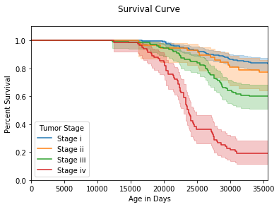

```python
from lifelines import KaplanMeierFitter
# T = age at death (or 35625 (max ageatdeath + 1) if alive)
T = np.asarray(clinical_info['age_at_death'])
T[np.isnan(T)] = 35625.0

# E is array where entry = false if still alive and true if dead
E = T != 35625.0

# plot different groups
grouped_kmf = pd.DataFrame()
grouped_kmf['T'] = T
grouped_kmf['E'] = E
grouped_kmf['group'] = list(clinical_info['tumor_stage'])

ax = plt.subplot(111)

kmf = KaplanMeierFitter()

for name, grouped_df in grouped_kmf.groupby('group'):
    kmf.fit(grouped_df["T"], grouped_df["E"], label=name)
    kmf.plot(ax=ax)

ax.set_ybound(0,1.1)
ax.set_xlabel("Age in Days")
ax.set_ylabel("Percent Survival")
ax.set_title("Survival Curve\n")
ax.legend(['Stage i', 'Stage ii', 'Stage iii', 'Stage iv'], title = "Tumor Stage")

plt.show()
```

# Whole Patient Object-Oriented Idea

I wanted to try out using an object-oriented approach for integrating the different data types. It ended up being somewhat superfluous, but here it is.

```python
# Read in RNA_Seq data (PROCESSING EXPLAINED LATER)
RNA_Seq = pd.read_csv("~/Desktop/Academics/stash/Primary_Tumor_FPKM.csv", index_col=0)
```

```python
# Define object to hold all available patient data types
class whole_patient:
    def __init__(self, clinical, RNA_seq, patient_IDs, target, unit_cost=0):
        self.clinical = clinical
        self.RNA_seq = RNA_seq
        self.patient_IDs = patient_IDs
        self.target = target
        self.unit_cost = unit_cost

whole_patient = whole_patient(clinical=clinical_info_without_target,
                              RNA_seq=RNA_Seq,
                              patient_IDs=clinical_info.index,
                              target=clinical_info['tumor_stage'])
```

```python
# Create function for getting all of the paired patient IDs and Tumor stages
def get_tumor_stages(self):
        dicts = {}
        keys = whole_patient.patient_IDs
        values = whole_patient.target
        for i in keys:
            dicts[i] = values[i]
        return(dicts)

# Use function on object
tumor_stages = get_tumor_stages(whole_patient)
pd.DataFrame.from_dict(tumor_stages, orient='index').head()
```

|  | 0 |
| --- | --- |
| TCGA-BP-5198 | 3.0 |
| TCGA-B0-4706 | 3.0 |
| TCGA-BP-4760 | 1.0 |
| TCGA-CZ-5462 | 4.0 |
| TCGA-AK-3427 | 1.0 |

And now for some machine learning

[figure not shown]

# Pre-processing

# pd.get_dummies() to combine factor data with numerics

```python
# Encode factor data and replace the NaN's with 0
whole_patient.clinical = pd.get_dummies(whole_patient.clinical, dummy_na=True)
whole_patient.clinical = whole_patient.clinical.replace(np.nan, 0)
```

# Data normalization

- I went with Normalizing and then using MinMax scaling because I want to normalize across the unit vector, and then scale the data between 0 and 1 to be compared to the binary dummy variables
- As I'm sure many of you could guess, this was basically a post-rationalization I made because the eventual clustering looked better :)

```python
# Normalize Data, and then MinMax Scale it
from sklearn.preprocessing import Normalizer, MinMaxScaler
# using normalizer
norm = Normalizer()
norm.fit(whole_patient.clinical)
whole_patient.clinical = pd.DataFrame(norm.fit_transform(whole_patient.clinical), columns=whole_patient.clinical.columns, index=whole_patient.clinical.index)
# and then using MinMaxScaler
MMS = MinMaxScaler()
MMS.fit(whole_patient.clinical)
whole_patient.clinical = pd.DataFrame(MMS.fit_transform(whole_patient.clinical), columns=whole_patient.clinical.columns, index=whole_patient.clinical.index)
```

# Principle Component Analysis

```python
# Principle Component Analysis
from sklearn.decomposition import PCA
import seaborn as sb
pca = PCA(n_components = 9)
pca_of_clinical = pca.fit(whole_patient.clinical).transform(whole_patient.clinical)

# Percentage of variance explained for each components
print('explained variance ratio (first two components): %s'
      % str(pca.explained_variance_ratio_))
```

```
explained variance ratio (first two components): [0.52542288 0.14232633 0.09238113 0.07234139 0.04006035 0.03652315
 0.02812212 0.01833828 0.01606816]
```

```python
# Create Dataframe of Clinical PCA Values
clinical_PCA = pd.DataFrame()
clinical_PCA['PC1'] = pca_of_clinical[:,0]
clinical_PCA['PC2'] = pca_of_clinical[:,1]
clinical_PCA['PC3'] = pca_of_clinical[:,2]
clinical_PCA['PC4'] = pca_of_clinical[:,3]
clinical_PCA['PC5'] = pca_of_clinical[:,4]
clinical_PCA['PC6'] = pca_of_clinical[:,5]
clinical_PCA['PC7'] = pca_of_clinical[:,6]
clinical_PCA['PC8'] = pca_of_clinical[:,7]
clinical_PCA['PC9'] = pca_of_clinical[:,8]
clinical_PCA.index = whole_patient.clinical.index
```

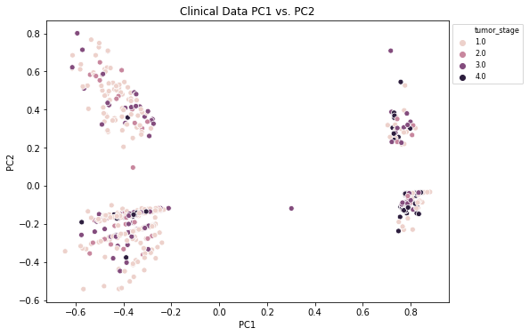

```python
# Plot Clinical PC1 vs. PC2
plt.figure(figsize=(10,7))
sb.scatterplot(x='PC1', y='PC2', data=clinical_PCA, hue=whole_patient.target, legend='brief');
plt.title('Clinical Data PC1 vs. PC2')
plt.legend(loc='upper left', prop={'size':8}, bbox_to_anchor=(1,1))
plt.tight_layout(pad=7)
plt.show()
```

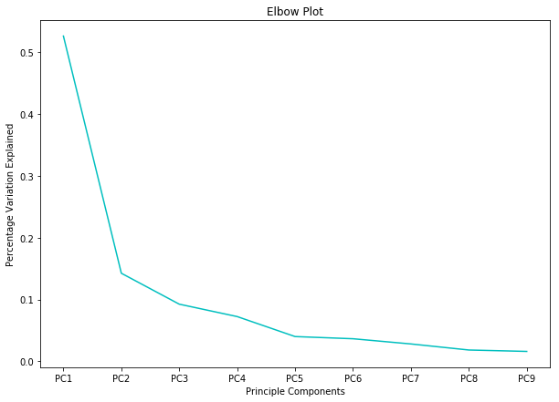

```python
# Elbow Plot of Principle Components
df = pd.DataFrame({'var':pca.explained_variance_ratio_,
             'PC':['PC1','PC2','PC3','PC4', 'PC5', 'PC6', 'PC7', 'PC8', 'PC9']})
plt.figure(figsize=(10,7))
sb.lineplot(x='PC',y="var",
           data=df, color="c")
plt.title('Elbow Plot')
plt.xlabel('Principle Components')
plt.ylabel('Percentage Variation Explained')
plt.show()
```

```python
# Elbow is at PC4, don't need others
clinical_PCA = clinical_PCA.drop(['PC5', 'PC6', 'PC7', 'PC8', 'PC9'], axis = 1)
```